# Customer value map

## Identifying the most valuable households

We will answer the question: "Who are our most valuable households today and how are they distributed by size, share, and characteristics?"

## Business framing

We’re analyzing value at the household level so marketing, pricing, and retention teams can target wallets, coupons, and churn actions where they matter most. Transactions span Days 1–711 (2017-01-01 to 2018-12-12), giving us a current view of spend and cadence. We’ll use business-facing RFM metrics and Lecture 3–style clustering to map households into actionable segments for offers and outreach.

## Intermediate technical output: environment setup

We verify the project path, add the repo to sys.path, configure plotting defaults, and set the output directories so the rest of the notebook runs reproducibly on the curated dataset in order to answer the question: "Do we have a reproducible analytical environment and base dataset that lets business teams revisit the value map as customers evolve?"

```python
from pathlib import Path
import sys

import matplotlib.pyplot as plt
import numpy as np
import pandas as pd

PROJECT_DIR = Path().resolve()
if str(PROJECT_DIR) not in sys.path:
    sys.path.append(str(PROJECT_DIR))

from functions import (
    load_customer_value_dataset,
    compute_household_rfm,
    score_rfm_table,
    label_rfm_segments,
    prepare_clustering_features,
    evaluate_kmeans_range,
    fit_kmeans_model,
    summarize_clusters,
    plot_rfm_scatter,
    plot_rfm_heatmap,
    plot_elbow_curve,
    plot_silhouette_curve,
    plot_cluster_profile,
)

DATA_PATH = PROJECT_DIR / "data" / "customer_value_dataset.parquet"
OUTPUT_DIR = PROJECT_DIR / "outputs"
OUTPUT_DIR.mkdir(exist_ok=True)

pd.set_option("display.float_format", lambda x: f"{x:,.2f}")
plt.style.use("seaborn-v0_8")
```

## Intermediate technical output: load curated dataset

We start by loading the cleaned household-level dataset produced by the prep pipeline so every analysis block works off a consistent, de-duplicated source.

```python
raw_df = load_customer_value_dataset(DATA_PATH)
date_range = (raw_df["TXN_DATE"].min(), raw_df["TXN_DATE"].max())
hh_lookup = (
    raw_df[
        [
            "household_key",
            "HOMEOWNER_DESC",
            "KID_CATEGORY_DESC",
            "classification_1",
        ]
    ]
    .drop_duplicates("household_key")
)

print(f"Rows: {len(raw_df):,}")
print(f"Households: {raw_df['household_key'].nunique():,}")
print(f"Baskets: {raw_df['BASKET_ID'].nunique():,}")
print(f"Date range: {date_range[0].date()} to {date_range[1].date()}")
raw_df.head()
```

```
Rows: 2,580,564
Households: 2,500
Baskets: 275,552
Date range: 2017-01-01 to 2018-12-12
```

|  | household_key | BASKET_ID | DAY | TXN_DATE | WEEK_NO | STORE_ID | PRODUCT_ID | DEPARTMENT | COMMODITY_DESC | SUB_COMMODITY_DESC | ... | RETAIL_DISC | COUPON_DISC | COUPON_MATCH_DISC | classification_1 | classification_2 | classification_3 | classification_4 | classification_5 | HOMEOWNER_DESC | KID_CATEGORY_DESC |
| --- | --- | --- | --- | --- | --- | --- | --- | --- | --- | --- | --- | --- | --- | --- | --- | --- | --- | --- | --- | --- | --- |
| 0 | 2375 | 26984851472 | 1 | 2017-01-01 | 1 | 364 | 1004906 | PRODUCE | POTATOES | POTATOES RUSSET (BULK&BAG) | ... | -0.60 | 0.00 | 0.00 | None | None | None | None | None | None | None |
| 1 | 2375 | 26984851472 | 1 | 2017-01-01 | 1 | 364 | 1033142 | PRODUCE | ONIONS | ONIONS SWEET (BULK&BAG) | ... | 0.00 | 0.00 | 0.00 | None | None | None | None | None | None | None |
| 2 | 2375 | 26984851472 | 1 | 2017-01-01 | 1 | 364 | 1036325 | PRODUCE | VEGETABLES - ALL OTHERS | CELERY | ... | -0.30 | 0.00 | 0.00 | None | None | None | None | None | None | None |
| 3 | 2375 | 26984851472 | 1 | 2017-01-01 | 1 | 364 | 1082185 | PRODUCE | TROPICAL FRUIT | BANANAS | ... | 0.00 | 0.00 | 0.00 | None | None | None | None | None | None | None |
| 4 | 2375 | 26984851472 | 1 | 2017-01-01 | 1 | 364 | 8160430 | PRODUCE | ORGANICS FRUIT & VEGETABLES | ORGANIC CARROTS | ... | -0.39 | 0.00 | 0.00 | None | None | None | None | None | None | None |

5 rows × 26 columns

## Analysis output: dataset overview (business value)

We confirm household counts, date coverage, and typical spend/visit cadence before segmenting, so later RFM and clustering steps rest on a vetted dataset.

```python
basket_values = raw_df.groupby("BASKET_ID")["NET_SPEND"].sum()
dataset_overview = pd.DataFrame(
    {
        "Metric": [
            "Transaction rows",
            "Households",
            "Unique baskets",
            "Unique products",
            "Total net spend (USD)",
            "Median basket net spend (USD)",
        ],
        "Value": [
            len(raw_df),
            raw_df["household_key"].nunique(),
            raw_df["BASKET_ID"].nunique(),
            raw_df["PRODUCT_ID"].nunique(),
            raw_df["NET_SPEND"].sum(),
            basket_values.median(),
        ],
    }
)
dataset_overview
```

|  | Metric | Value |
| --- | --- | --- |
| 0 | Transaction rows | 2,580,564.00 |
| 1 | Households | 2,500.00 |
| 2 | Unique baskets | 275,552.00 |
| 3 | Unique products | 91,994.00 |
| 4 | Total net spend (USD) | 9,495,639.91 |
| 5 | Median basket net spend (USD) | 19.98 |

In this analysis, we're handling 2.58 million line items coming from 2,500 households and 275,552 baskets that span almost two years. The store captured nearly 9.5 million dollars of net spend in that horizon while the typical basket is worth about 20 dollars. Lecture 2 reminded us that RFM needs a full behavioral trail, so we noted that the two year window plus basket identifiers gave us a solid coverage of recency, frequency, and monetary signals before we score households.

## Analysis output: RFM segmentation

We compute household-level R/F/M scores to anchor the business-facing segments used later.

The next RFM visuals show where households sit before clustering.

```python
rfm = compute_household_rfm(raw_df)
rfm = rfm.merge(hh_lookup, on="household_key", how="left")
rfm = score_rfm_table(rfm)
rfm = label_rfm_segments(rfm)
rfm.head()
```

|  | household_key | recency_days | frequency | monetary_value | total_units | active_weeks | avg_basket_value | avg_units_per_basket | lifetime_value | HOMEOWNER_DESC | KID_CATEGORY_DESC | classification_1 | R_score | F_score | M_score | rfm_total | rfm_code | segment |
| --- | --- | --- | --- | --- | --- | --- | --- | --- | --- | --- | --- | --- | --- | --- | --- | --- | --- | --- |
| 0 | 1023 | 2 | 601 | 40,497.69 | 4479914 | 84 | 67.38 | 7,454.10 | 40,497.69 | None | None | None | 5 | 5 | 5 | 15 | 555 | Champions |
| 1 | 1609 | 1 | 408 | 30,371.52 | 2146712 | 95 | 74.44 | 5,261.55 | 30,371.52 | Homeowner | 3+ | Age Group4 | 5 | 5 | 5 | 15 | 555 | Champions |
| 2 | 2322 | 1 | 323 | 26,027.11 | 992718 | 91 | 80.58 | 3,073.43 | 26,027.11 | Homeowner | None/Unknown | Age Group4 | 5 | 5 | 5 | 15 | 555 | Champions |
| 3 | 2459 | 8 | 970 | 24,885.29 | 488789 | 94 | 25.65 | 503.91 | 24,885.29 | None | None | None | 3 | 5 | 5 | 13 | 355 | Growth regulars |
| 4 | 1453 | 2 | 761 | 24,532.06 | 95743 | 87 | 32.24 | 125.81 | 24,532.06 | Homeowner | 1 | Age Group4 | 5 | 5 | 5 | 15 | 555 | Champions |

Quintile Scoring Applied:

- Each metric scored 1-5 (quintiles)
- Recency reversed (lower days = higher score)
- Combined RFM score: 3-15

```python
total_households = rfm["household_key"].nunique()
total_value = rfm["monetary_value"].sum()
segment_summary = (
    rfm.groupby("segment")
    .agg(
        households=("household_key", "nunique"),
        median_recency=("recency_days", "median"),
        median_frequency=("frequency", "median"),
        median_monetary=("monetary_value", "median"),
        total_value=("monetary_value", "sum"),
    )
    .sort_values("median_monetary", ascending=False)
)
segment_summary["household_share_pct"] = (
    segment_summary["households"] / total_households * 100
)
segment_summary["revenue_share_pct"] = (
    segment_summary["total_value"] / total_value * 100
)
segment_summary = segment_summary.reset_index()
segment_summary = segment_summary[
    [
        "segment",
        "households",
        "household_share_pct",
        "median_recency",
        "median_frequency",
        "median_monetary",
        "revenue_share_pct",
    ]
]
segment_summary
```

|  | segment | households | household_share_pct | median_recency | median_frequency | median_monetary | revenue_share_pct |
| --- | --- | --- | --- | --- | --- | --- | --- |
| 0 | Champions | 525 | 21.00 | 2.00 | 198.00 | 7,084.68 | 47.00 |
| 1 | Growth regulars | 296 | 11.84 | 7.00 | 119.00 | 4,459.92 | 16.59 |
| 2 | At risk loyalists | 155 | 6.20 | 21.00 | 138.00 | 4,372.18 | 8.12 |
| 3 | Loyal enthusiasts | 296 | 11.84 | 2.00 | 92.00 | 2,702.52 | 9.26 |
| 4 | Needs nurturing | 387 | 15.48 | 9.00 | 63.00 | 1,811.14 | 8.90 |
| 5 | New customers | 179 | 7.16 | 2.00 | 39.00 | 1,200.92 | 2.73 |
| 6 | Dormant households | 662 | 26.48 | 36.00 | 29.00 | 809.56 | 7.40 |

Lecture 2 emphasised profiling segments for both size and value before naming them, so we read this RFM table through that lens. We have 7 distinct buying groups.

### Business value plot: household RFM landscape

We will generate a scatter of recency vs frequency colored by spend highlights where value concentrates and where outliers sit, giving a visual check on household behavior before formal clustering

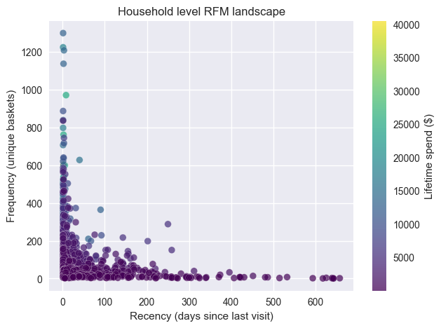

```python
ax = plot_rfm_scatter(
    rfm,
    output_path=str(OUTPUT_DIR / "rfm_scatter.png"),
)
plt.show()
```

Plot takeaway: The households with recency below ten days and frequency above 200 dominate monetary value, so real time campaigns must prioritize this tight cluster before their recency worsens.

### Business value plot: Recency Frequency heatmap

Heatmap of R vs F counts shows where households concentrate across the score grid; confirms that the scoring behaves as expected before deeper modeling.

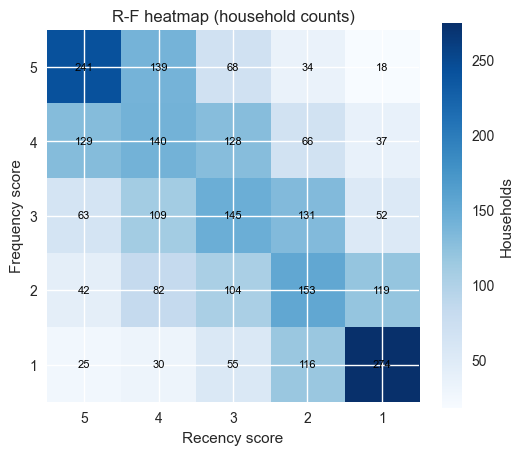

```python
ax = plot_rfm_heatmap(
    rfm,
    output_path=str(OUTPUT_DIR / "rfm_heatmap.png"),
)
plt.show()
```

Plot takeaway: The heatmap shows household counts concentrated in high-frequency/low-recency cells (Champions/Growth) and a large block in low-frequency/high-recency (Dormant).

### Business value plot: segment size distribution

We will create a bar chart of household counts (and share) by RFM segment to spot which cohorts dominate; this sanity check on balance helps set up the k-means step that follows to see if finer clusters add value.

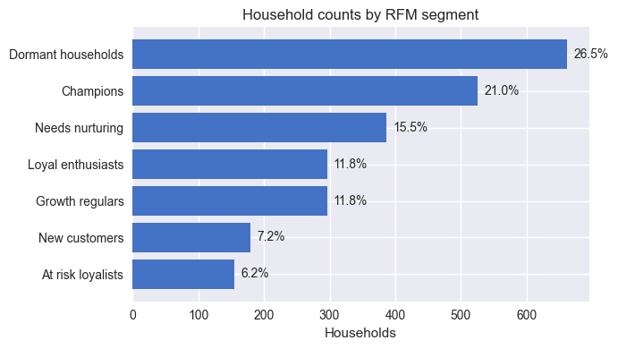

```python
segment_counts = rfm["segment"].value_counts().sort_values()
fig, ax = plt.subplots(figsize=(7, 4))
ax.barh(segment_counts.index, segment_counts.values, color="#4472C4")
ax.set_xlabel("Households")
ax.set_title("Household counts by RFM segment")
for i, value in enumerate(segment_counts.values):
    ax.text(value + 10, i, f"{value / total_households * 100:,.1f}%", va="center")
fig.tight_layout()
fig.savefig(OUTPUT_DIR / "segment_distribution.png", bbox_inches="tight", dpi=150)
plt.show()
```

Traditional RFM Segments Identified:

1. Dormant Households - 26.5% of HH, 7.4% of revenue
2. Champions - 21% of HH, 47% of revenue
3. Needs nurturing - 15.5% of HH, 8.9% of revenue
4. Loyal enthusiasts - 11.8% of HH, 9.26% of revenue
5. Growth regulars - 11.8% of HH, 16.59% of revenue
6. New customers - 7.2% of HH, 2.73% of revenue
7. At Risk - 6.2% of HH, 8.12% of revenue

### Intermediate technical output: Lecture 3 clustering prep

Lecture 3 told us to standardise the behavioral drivers, engineer log features for skewed spend fields, and test several k values with the elbow and silhouette diagnostics before trusting any cluster story, so the next block sets up those steps. We’re clustering on a handpicked RFM/log feature set and are not applying PCA or other dimensionality reduction. The feature count is small and interpretable as-is; if we expand the feature space later, we can add PCA before k-means to stabilize distances.

RQ: How many distinct behavioral clusters exist beyond simple RFM tiers, and does splitting households further unlock clearer promotional tactics?

```python
features, scaler = prepare_clustering_features(rfm)
k_range = range(2, 7)
k_metrics = evaluate_kmeans_range(features, k_range)
k_metrics
```

|  | k | inertia | silhouette | min_cluster | min_cluster_share_pct | below_min_share |
| --- | --- | --- | --- | --- | --- | --- |
| 0 | 2 | 10,683.48 | 0.37 | 0 | 47.80 | False |
| 1 | 3 | 8,501.30 | 0.31 | 2 | 19.32 | False |
| 2 | 4 | 6,934.63 | 0.33 | 1 | 2.44 | False |
| 3 | 5 | 5,825.80 | 0.33 | 4 | 2.44 | False |
| 4 | 6 | 5,077.63 | 0.29 | 4 | 1.88 | False |

The original 7 specific buying groups have been divided into clusters according to their characteristics. We’re testing k=2–6 instead of the 5–15 heuristic mentioned in Lecture 3 because the sample size and business context favor fewer, broader segments. If stability looks good, we can revisit a wider k range later

Lecture 3 also asked us to keep cluster sizes reasonable, so we rerun the k-range diagnostic with a 5% minimum-cluster share to spot any unstable k. We didn’t one-hot encode categoricals because the k-means features are purely numeric RFM/log fields. The categorical columns are only pulled in later for profiling cluster composition, so feeding dummies into the distance calculation wasn’t necessary for this run

```python
k_metrics2 = evaluate_kmeans_range(features, k_range, min_cluster_share=0.05)
k_metrics2
```

|  | k | inertia | silhouette | min_cluster | min_cluster_share_pct | below_min_share |
| --- | --- | --- | --- | --- | --- | --- |
| 0 | 2 | 10,683.48 | 0.37 | 0 | 47.80 | False |
| 1 | 3 | 8,501.30 | 0.31 | 2 | 19.32 | False |
| 2 | 4 | 6,934.63 | 0.33 | 1 | 2.44 | True |
| 3 | 5 | 5,825.80 | 0.33 | 4 | 2.44 | True |
| 4 | 6 | 5,077.63 | 0.29 | 4 | 1.88 | True |

### Intermediate technical plot: elbow diagnostic

Elbow curve for k=2–6 (we kept it tight by design) to see where the inertia gains start to flatten. We will read it together with the 5% minimum cluster-share flag so we don’t pick a k that creates unstable, tiny clusters

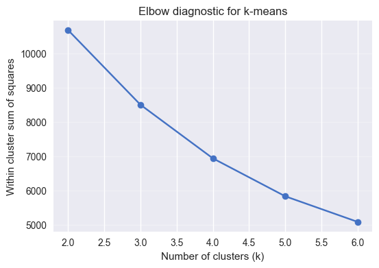

```python
ax = plot_elbow_curve(
    k_metrics,
    output_path=str(OUTPUT_DIR / "elbow_curve.png"),
)
plt.show()
```

Plot takeaway: The within cluster sum of squares softly flattens beyond k equals four, so four clusters balance fit and simplicity. In this chart, the elbow is not very clear

### Intermediate technical plot: silhouette diagnostic

Silhouette scores for the same k=2–6 range as the elbow plot. Higher is better; pair this with the 5% cluster-share guardrail so we don’t get fooled by a ‘good’ score that hides a tiny, unstable cluster

We pick the k that balances inertia, silhouette, and the 5% minimum, then summarize clusters below.

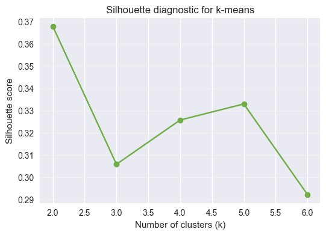

```python
ax = plot_silhouette_curve(
    k_metrics,
    output_path=str(OUTPUT_DIR / "silhouette_curve.png"),
)
plt.show()
```

## Analysis output: Lecture 3 style k-means clusters

```python
OPTIMAL_K = 4
kmeans_model, assignments = fit_kmeans_model(features, OPTIMAL_K)
cluster_summary, cat_tables = summarize_clusters(
    rfm,
    assignments,
    categorical_cols=[
        "HOMEOWNER_DESC",
        "KID_CATEGORY_DESC",
        "classification_1",
    ],
)
cluster_summary
```

|  | cluster | households | recency_days | frequency | monetary_value | avg_basket_value | r_score | f_score | m_score | rfm_total | household_share_pct |
| --- | --- | --- | --- | --- | --- | --- | --- | --- | --- | --- | --- |
| 2 | 2 | 392 | 2.00 | 252.50 | 9,675.79 | 38.56 | 5.00 | 5.00 | 5.00 | 14.00 | 15.68 |
| 0 | 0 | 1114 | 5.00 | 105.50 | 3,451.48 | 33.85 | 3.00 | 4.00 | 4.00 | 10.00 | 44.56 |
| 3 | 3 | 933 | 18.00 | 34.00 | 967.89 | 29.57 | 2.00 | 2.00 | 2.00 | 5.00 | 37.32 |
| 1 | 1 | 61 | 295.00 | 7.00 | 202.53 | 27.68 | 1.00 | 1.00 | 1.00 | 3.00 | 2.44 |

- Cluster 2 overlaps with the Champions RFM tier (58 percent of that group) and the highest-value Growth Regulars, visiting every couple of days (~250 baskets) and spending $9.7K, so it deserves premium loyalty treatment.
- Cluster 0 concentrates the Growth Regulars, Loyal Enthusiasts, and most At Risk Loyalists (45 percent of households) with ~105 trips and $3.4K spend, making it the bounce-back and milestone journey pool that can graduate into Champions.
- Cluster 3, plus the tiny Cluster 1, aligns with the Needs Nurturing and Dormant households (86 percent of Dormant shoppers live in Cluster 3), showing 18-day recency in Cluster 3 and 295 days in Cluster 1, so this duo defines the churn-prevention backlog that needs reactivation pushes.

### Business value plot: normalized cluster profiles

We build a normalized bar chart to quickly compare clusters without unit bias. Normalizing recency, frequency and spend lets us see which clusters are leaders or laggards at a glance, so we can prioritize who gets premium offers

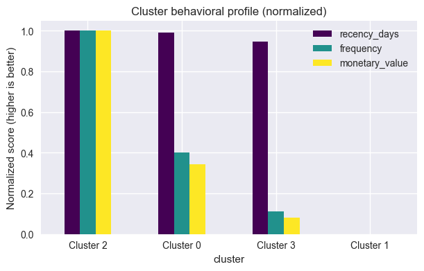

```python
ax = plot_cluster_profile(
    cluster_summary,
    cols=["recency_days", "frequency", "monetary_value"],
    output_path=str(OUTPUT_DIR / "cluster_profile.png"),
)
plt.show()
```

Plot takeaway: Cluster 2 dominates on spend and frequency and thus deserves white glove perks, Cluster 0 sits in the middle and should be nurtured upward, while Clusters 3 and 1 flag churn risk.

### Analysis output: demographic signals per cluster

Categorical breakouts (homeownership, kids, etc.) show how each cluster skews on demographics; these are for profiling only since categoricals were not used in distance calculations.

```python
for name, table in cat_tables.items():
    print(f"--- {name} ---")
    display(table.head(10))

#test
```

```
--- HOMEOWNER_DESC ---
```

|  | cluster | HOMEOWNER_DESC | households | share_pct |
| --- | --- | --- | --- | --- |
| 0 | 0 | Homeowner | 312 | 63.03 |
| 4 | 0 | Unknown | 147 | 29.70 |
| 3 | 0 | Renter | 22 | 4.44 |
| 2 | 0 | Probable Renter | 8 | 1.62 |
| 1 | 0 | Probable Owner | 6 | 1.21 |
| 5 | 2 | Homeowner | 175 | 62.72 |
| 9 | 2 | Unknown | 76 | 27.24 |
| 8 | 2 | Renter | 20 | 7.17 |
| 6 | 2 | Probable Owner | 5 | 1.79 |
| 7 | 2 | Probable Renter | 3 | 1.08 |

```
--- KID_CATEGORY_DESC ---
```

|  | cluster | KID_CATEGORY_DESC | households | share_pct |
| --- | --- | --- | --- | --- |
| 3 | 0 | None/Unknown | 364 | 73.54 |
| 0 | 0 | 1 | 63 | 12.73 |
| 2 | 0 | 3+ | 38 | 7.68 |
| 1 | 0 | 2 | 30 | 6.06 |
| 7 | 2 | None/Unknown | 176 | 63.08 |
| 4 | 2 | 1 | 46 | 16.49 |
| 5 | 2 | 2 | 29 | 10.39 |
| 6 | 2 | 3+ | 28 | 10.04 |
| 11 | 3 | None/Unknown | 18 | 66.67 |
| 8 | 3 | 1 | 5 | 18.52 |

```
--- classification_1 ---
```

|  | cluster | classification_1 | households | share_pct |
| --- | --- | --- | --- | --- |
| 3 | 0 | Age Group4 | 178 | 35.96 |
| 2 | 0 | Age Group3 | 109 | 22.02 |
| 1 | 0 | Age Group2 | 87 | 17.58 |
| 5 | 0 | Age Group6 | 51 | 10.30 |
| 4 | 0 | Age Group5 | 40 | 8.08 |
| 0 | 0 | Age Group1 | 30 | 6.06 |
| 9 | 2 | Age Group4 | 101 | 36.20 |
| 8 | 2 | Age Group3 | 78 | 27.96 |
| 7 | 2 | Age Group2 | 50 | 17.92 |
| 10 | 2 | Age Group5 | 19 | 6.81 |

### Analysis output: how RFM segments map into k-means clusters

Cross-tab RFM segments vs k-means clusters to sanity-check that the new clusters refine (not contradict) the simple RFM tiers. If the mapping looks off, we’ll revisit feature choices or k

```python
segment_cluster = (
    rfm.merge(assignments, on="household_key")
    .groupby(["segment", "cluster"])["household_key"]
    .nunique()
    .reset_index(name="households")
)
segment_cluster["segment_total"] = segment_cluster.groupby("segment")["households"].transform("sum")
segment_cluster["share_within_segment_pct"] = (
    segment_cluster["households"] / segment_cluster["segment_total"] * 100
)
segment_cluster.sort_values(["segment", "cluster"])
```

|  | segment | cluster | households | segment_total | share_within_segment_pct |
| --- | --- | --- | --- | --- | --- |
| 0 | At risk loyalists | 0 | 130 | 155 | 83.87 |
| 1 | At risk loyalists | 2 | 25 | 155 | 16.13 |
| 2 | Champions | 0 | 221 | 525 | 42.10 |
| 3 | Champions | 2 | 304 | 525 | 57.90 |
| 4 | Dormant households | 0 | 29 | 662 | 4.38 |
| 5 | Dormant households | 1 | 61 | 662 | 9.21 |
| 6 | Dormant households | 3 | 572 | 662 | 86.40 |
| 7 | Growth regulars | 0 | 238 | 296 | 80.41 |
| 8 | Growth regulars | 2 | 57 | 296 | 19.26 |
| 9 | Growth regulars | 3 | 1 | 296 | 0.34 |
| 10 | Loyal enthusiasts | 0 | 271 | 296 | 91.55 |
| 11 | Loyal enthusiasts | 2 | 6 | 296 | 2.03 |
| 12 | Loyal enthusiasts | 3 | 19 | 296 | 6.42 |
| 13 | Needs nurturing | 0 | 203 | 387 | 52.45 |
| 14 | Needs nurturing | 3 | 184 | 387 | 47.55 |
| 15 | New customers | 0 | 22 | 179 | 12.29 |
| 16 | New customers | 3 | 157 | 179 | 87.71 |

Champions split mostly into Cluster 2 (58%) with the balance in Cluster 0, which validates that the cluster cut respects the Lecture 2 RFM logic. Dormant households flow into Cluster 3 (86%) and the extreme laggards (Cluster 1) so we can treat Cluster 3 as the recovery pool. At risk loyalists sit mostly in Cluster 0 even though their recency worsened, signaling they respond if we create trigger campaigns before they slide into Cluster 3, which is consistent with the test and learn loop described in Lecture 2.

## Final answer to the business question

Next steps focus on launching retention testing for Cluster 2, moving Cluster 0 households into a milestone loyalty journey, and running limited time win back offers for Cluster 3 that stress price matched essentials because 86 percent of Dormant households live there, which keeps us aligned with the test and learn mindset from Lecture 2 and the profiling guidance from Lecture 3.